# Hierarchical Clustering

Tutorial ini adalah bagian dari mata kuliah Fundamental Sains Data, Prodi Sarjana Informatika, UII.

#### Data USArrests

Pada contoh ini kita akan menggunakan sebuah data set `USArrest`, yang disediakan oleh package `datasets`. Data ini berisi statistik pengangkapan penjahat per 100.000 penduduk pada 50 negara bagian di U.S. pada tahun 1973, yang berdasarkan tiga jenis tindak kejahatan: penyerangan (`Assault`), pembunuhan (`Murder`), dan pemerkosaan (`Rape`), serta presentase penduduk yang tinggal di daerah urban.

Pertama, mari kita lihat lebih detail tentang data tersebut.

```r
USArrests
```

|  | Murder | Assault | UrbanPop | Rape |
| --- | --- | --- | --- | --- |
| Alabama | 13.2 | 236 | 58 | 21.2 |
| Alaska | 10.0 | 263 | 48 | 44.5 |
| Arizona | 8.1 | 294 | 80 | 31.0 |
| Arkansas | 8.8 | 190 | 50 | 19.5 |
| California | 9.0 | 276 | 91 | 40.6 |
| Colorado | 7.9 | 204 | 78 | 38.7 |
| Connecticut | 3.3 | 110 | 77 | 11.1 |
| Delaware | 5.9 | 238 | 72 | 15.8 |
| Florida | 15.4 | 335 | 80 | 31.9 |
| Georgia | 17.4 | 211 | 60 | 25.8 |

[output cut: 40 more lines]

```r
summary(USArrests)
```

```
##      Murder          Assault         UrbanPop          Rape
##  Min.   : 0.800   Min.   : 45.0   Min.   :32.00   Min.   : 7.30
##  1st Qu.: 4.075   1st Qu.:109.0   1st Qu.:54.50   1st Qu.:15.07
##  Median : 7.250   Median :159.0   Median :66.00   Median :20.10
##  Mean   : 7.788   Mean   :170.8   Mean   :65.54   Mean   :21.23
##  3rd Qu.:11.250   3rd Qu.:249.0   3rd Qu.:77.75   3rd Qu.:26.18
##  Max.   :17.400   Max.   :337.0   Max.   :91.00   Max.   :46.00
```

Sebuah alternatif untuk mendapatkan visualisasi dari setiap variabel adalah dengan menggunakan `barplot()`. Baris 1 membuat sebuat data frame dari data set `USArrest` dan menambahkan satu kolom berisi nama negara bagian (state). Baris 2 untuk mengubah orientasi label pada sumbu vertikal sehingga daapt terbaca secara horizontal (lihat nama negara bagian), dan Baris 3 untuk mengatur margin, sehingga possi barplot lebih di tengah. Baris 4 membuat barplot untuk variabel `Murder`; baris-barise selanjutnya membuat `barplot` untuk variabel lain.

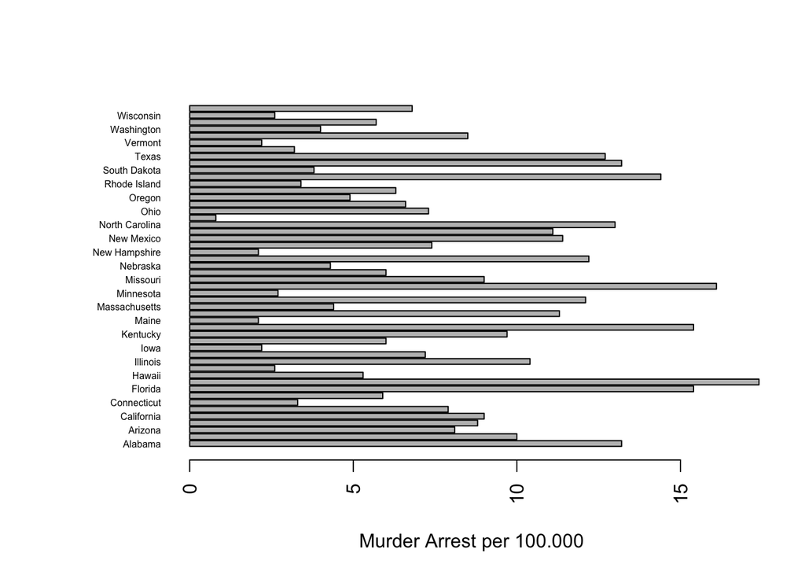

```r
df <- data.frame(States=rownames(USArrests), USArrests)
par(las=2) # make label text perpendicular to axis
par(mar=c(5,8,4,2)) # increase y-axis margin.
barplot(df$Murder, names.arg = df$States, horiz = TRUE, cex.names = 0.5, xlab = "Murder Arrest per 100.000")
```

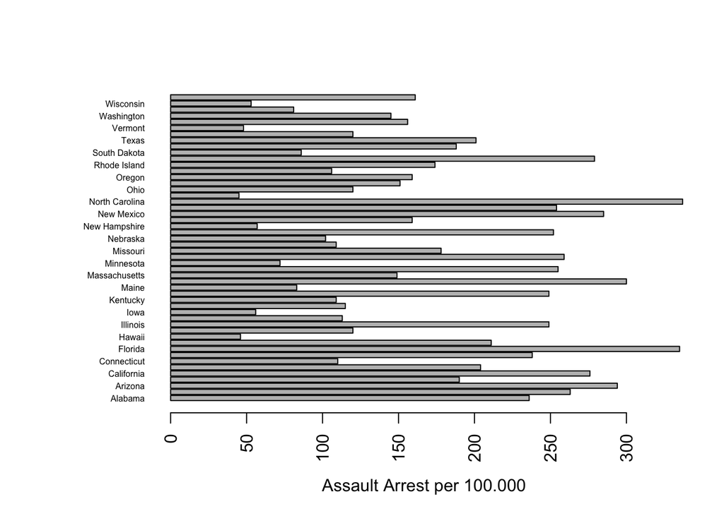

```r
barplot(df$Assault, names.arg = df$States, horiz = TRUE, cex.names = 0.5, xlab = "Assault Arrest per 100.000")
```

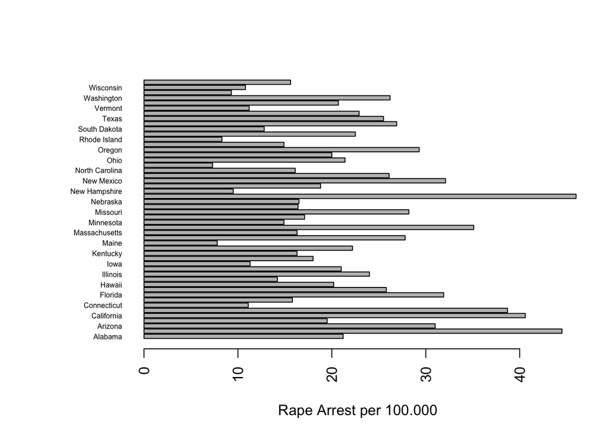

```r
barplot(df$Rape, names.arg = df$States, horiz = TRUE, cex.names = 0.5, xlab = "Rape Arrest per 100.000")
```

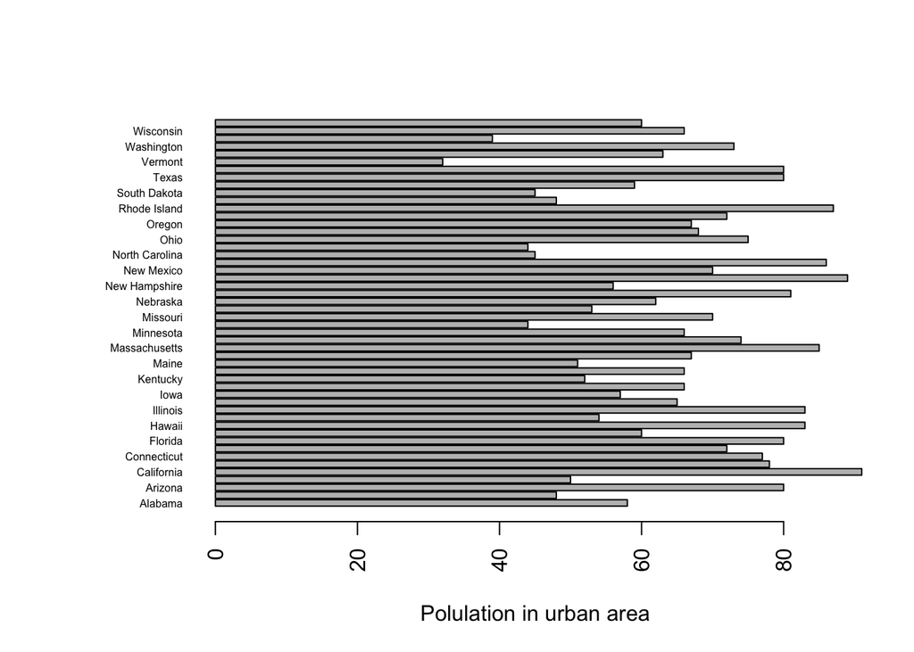

```r
barplot(df$UrbanPop, names.arg = df$States, horiz = TRUE, cex.names = 0.5, xlab = "Polulation in urban area")
```

Perhatikan sebaran setiap variabel berdasarakan empat barplot di atas, untuk mendapatkan insight tentang data.

#### Hierarchical Clustering

Di sini kita akan melakukan hierarchical clustering menggunakan fungsi `hclust`. Di sini kita hanya ingin menggunakan empat variabel (tanpa variabel `States`), maka kita hilangkan variabel tersebut lewat Baris 1. Fungsi `hclust` menerima matriks jarak (dissimilarity meassure dari setiap pasang variabel), maka kita menghitung matriks tersebut lewat Baris 2. Pada Baris 3, kita melakukan hiearchical clustering dengan metode `complete linkage` (lihat slide materi). Rekan-rekan bisa mencoba dengan `single`, `average`, dan metode lain (lihat `?hclust` untuk lebih jelasnya). Baris 4 membuat plot dendrogram dari hasil clustering; parameter `cex` emngatur besar font untuk label pada sumbu x, `hang` mengatur posisi label terhadap sumbu y.

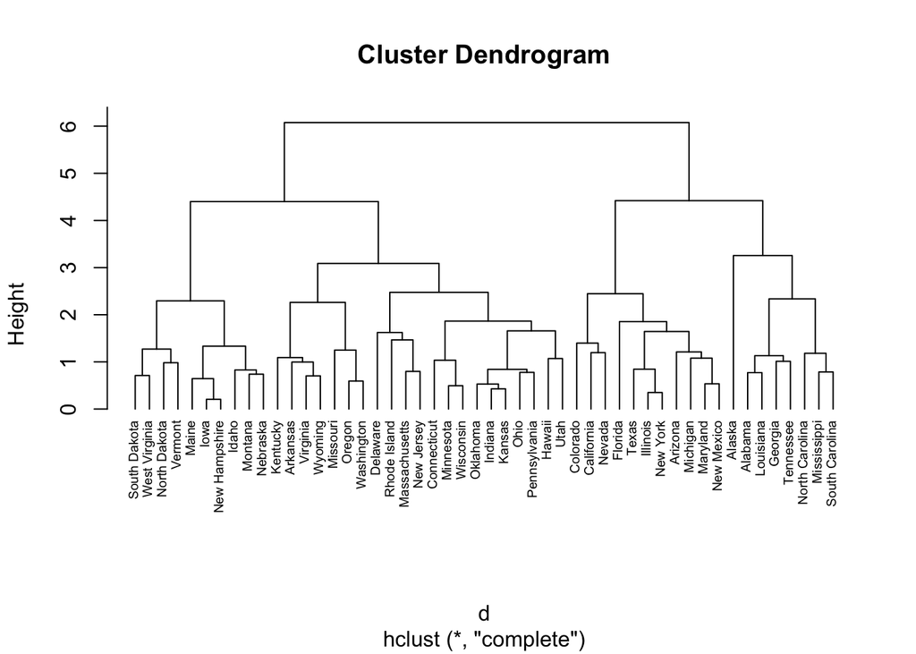

```r
df <- scale(df[, 2:5])
d <- dist(df, method = "euclidean")
clusters <- hclust(d, method = "complete" )
plot(clusters, cex = 0.6, hang = -1)
```

Kita dapat menggunakan fungsi `rect.hclust()` untuk menggambar kotak pada sejumlah klaster yang kita inginkan. Sebagai contoh, kita ingin melihat 4 klaster dari hasil clustering di atas. Maka kita set `k=4`. Parameter `border` mengatur warna kotak dari setiap klaster.

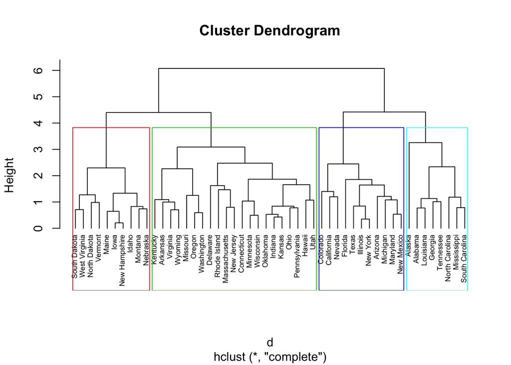

```r
plot(clusters, cex = 0.6, hang = -1)
rect.hclust(clusters, k = 4, border = 2:5)
```

#### Latihan

Cobalah hiearchical clustering pada data `USArrests` menggunakan metode `single` dan `average`. Amati perubahannya. Kemudian dengan masing-masing metode, lihat 4 (atau ubah nilai ini) klaster menggunakan `rect.hclust`, dan bandingkan juga keanggotaan setiap klaster, dari masing-masing metode.